# BankHWfile-Summary

RyanYip

```
## There is :%d NA value 0
```

```
##       age            education        contact        month
##  Min.   :20.00   primary  : 63   cellular :536   may    :185
##  1st Qu.:33.00   secondary:303   telephone: 28   apr    : 84
##  Median :38.00   tertiary :198                   0v     : 75
##  Mean   :41.05                                   feb    : 56
##  3rd Qu.:48.00                                   jan    : 36
##  Max.   :80.00                                   aug    : 34
##                                                  (Other): 94
##     campaign         poutcome         y
##  Min.   : 1.000   failure:452   Min.   :0.000
##  1st Qu.: 1.000   success:112   1st Qu.:0.000
##  Median : 1.000                 Median :0.000
##  Mean   : 1.927                 Mean   :0.234
##  3rd Qu.: 2.000                 3rd Qu.:0.000
##  Max.   :11.000                 Max.   :1.000
##
```

### Question 1

**Hypotheses 1: variable education has significant effect on output variable y,that is**

- H0:the coefficient of education is equal to 0 in logistic model
- H1: the coefficient of education is not equal to 0 in logistic model

**Hypotheses 2: variable age has significant effect on output variable y,that is**

- H0:the coefficient of age is equal to 0 in logistic model
- H1: the coefficient of age is not equal to 0 in logistic model

I conducted the hypotheses test of age and education because, according to common sense, these two variables have a relatively large relationship with the dependent variable, so I am interested and want to see if there is any influence.And in reality,It is stange that *education* and *age* should have effect on whether has the client subscribed a term deposit.o I suggest that the company can pay more attention to age and education level when considering customers,they mat be important message and need to be consider further.

### Question 2

#### preliminary analysis

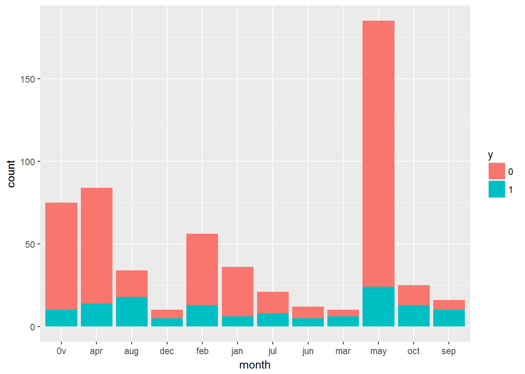

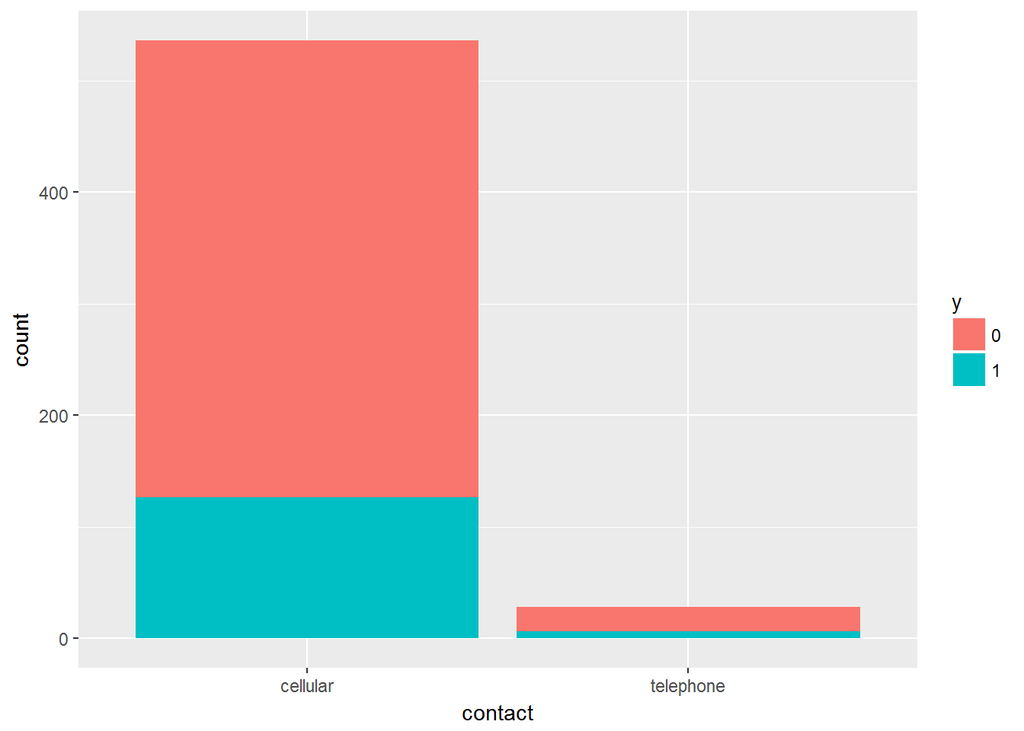

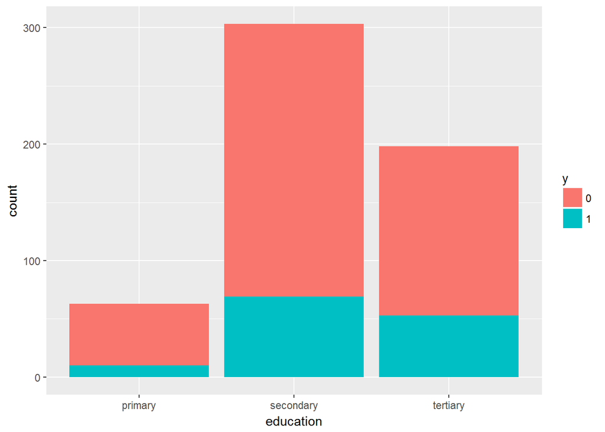

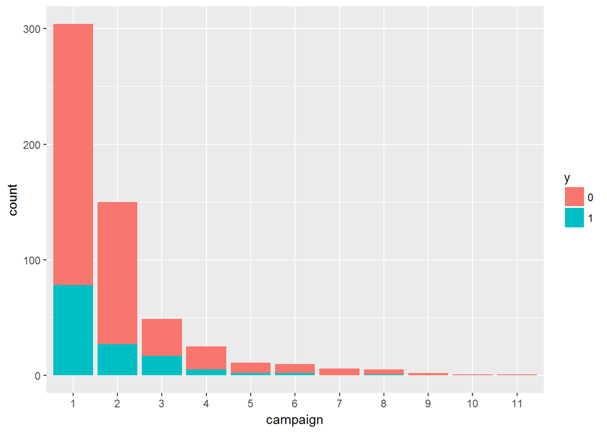

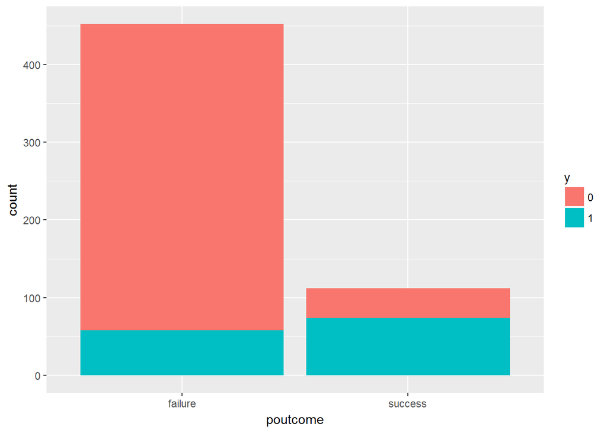

We make preliminary analysis on data by simple graph analysis,due to these variables are most categorical,so only do barplot.According to these plot,in *contact* variable,the numeber in celluar type is the most,but number of not having the client subscribed a term deposit also has big ratio;in *education*,the count in secondary is most. ;and in telephone has the same result;In *month*,I think responce(y) has a differnce across month,and last contact in **May** is the highest;And in *campain*, the most is in low level number,but in high number,it is almost that client has not subscribed a term deposit.In *poutcome*,it shows that when poutcome is fail,the more number of client has not subscribed a term deposit.

### Question 3

Corresponding to question 1,*age* and *education* are the two variables I want to test,So I control respectively.And I use all variables as predictor in full model.

The follow model I do not consider the relationship across predictors.

```r
model.full<-glm(y~age+education+contact+month+campaign+poutcome,data=BankHWWfile,family = "binomial") # with age,edu

model.reduce.edu<-glm(y~age+contact+month+campaign+poutcome,data=BankHWWfile,family = "binomial") # without edu
model.reduce.age<-glm(y~education+contact+month+campaign+poutcome,data = BankHWWfile,family = "binomial") #without age
#summary(model.full)
```

### Question 4

Interpret the output of model in Question 3

```
## Analysis of Deviance Table
##
## Model 1: y ~ age + education + contact + month + campaign + poutcome
## Model 2: y ~ age + contact + month + campaign + poutcome
##   Resid. Df Resid. Dev Df Deviance Pr(>Chi)
## 1       537     448.88
## 2       539     453.76 -2  -4.8782  0.08724 .
## ---
## Signif. codes:  0 '***' 0.001 '**' 0.01 '*' 0.05 '.' 0.1 ' ' 1
```

Accoring to the anova tables,we know that the p-value is larger than 0.05,that is,the **Hypotheses 1** is not significant,so we can not reject the H0,that is,variable *education* should not be in model,which means *education* has few effect on response variable *y*.

```
## Analysis of Deviance Table
##
## Model 1: y ~ age + education + contact + month + campaign + poutcome
## Model 2: y ~ education + contact + month + campaign + poutcome
##   Resid. Df Resid. Dev Df Deviance Pr(>Chi)
## 1       537     448.88
## 2       538     449.21 -1 -0.33103   0.5651
```

The result of age is similiar with education,the p-value is also larger than 0.05,so it is not significant and variable *age* should not be in model,which means *age* has few effect on response variable *y*.

According to the above result,they do not support my Hypotheses in statistics,which is not consistent with common sense?,may be I should take them into further consideration and consider other factors.